# Predict Probability of Sales on Inbound Call Center Traffic

## Project description

This project aims at predicting the sale on next call based on caller’s demographic, socio economic data, location and the source of traffic (paid, SEO or affiliate). A sale comprises sale of any combination of cable, internet or phone service to a residential caller in any part of US depending on the availability of service at the caller’s address. Call center sales agents have access to order entry tool for almost all the major cable, internet and phone service providers in the country which enables them to sell any provider the caller is looking for.

Ordering cable, internet and phone services is a complex process that requires customization and selection of many features on callers part and also because the price a customer pays on a monthly basis, varies with the choice of channels selection for a cable product, speed of internet package and in case of phone whether in-state or out-of-state calling is selected or not. People usually need assistance in order to order services and hence call in.

Before calling, callers generally search online to get an idea of what they should order and who to reach out to in order to get services. The search is mostly carried out on some of the popular search engines such as google, bing, yahoo etc. This particular call center markets its services on these search engines to generate demand and to drive calls to the center.

Data Source: In order to predict the sales outcome on a call, calls data for May 2016 has been used. Over 440K calls were offered in the call center in May of which about 400K calls got answered. The data is contained in an excel sheet. A summary of variables is obtained by running the summary() command on the read data.

```
## [1] "C/C/C/C/C/en_US.UTF-8"
```

```
##    CallDate         CallStartTime      CallEndTime
##  Length:409555      Length:409555      Length:409555
##  Class :character   Class :character   Class :character
##  Mode  :character   Mode  :character   Mode  :character
##
##
##
##    Outcome            AgentID               TFN
##  Length:409555      Length:409555      Min.   :2.153e+09
##  Class :character   Class :character   1st Qu.:8.444e+09
##  Mode  :character   Mode  :character   Median :8.552e+09
##                                        Mean   :8.016e+09
##                                        3rd Qu.:8.558e+09
##                                        Max.   :8.889e+09
##      BTN              CallSkill     OriginalSkill   CableCompany
##  Length:409555      Min.   :100.0   Min.   :  0.0   Length:409555
##  Class :character   1st Qu.:300.0   1st Qu.:301.0   Class :character
##  Mode  :character   Median :302.0   Median :302.0   Mode  :character
##                     Mean   :274.4   Mean   :310.4
##                     3rd Qu.:310.0   3rd Qu.:308.0
##                     Max.   :999.0   Max.   :999.0
##   Affiliate         Disposition
##  Length:409555      Length:409555
##  Class :character   Class :character
##  Mode  :character   Mode  :character
##
##
##
```

A brief description of the variables in the data set is as follows:

## Data Cleaning

The disposition of the call depends on a number of factors such as the area the caller was calling from, the affiliate that drove the call, call skill and the TFN. A more detailed explanation of each varilable and cleaning the data is presented below. 1. TFN

```
## [1] 5417
```

2. BTN : The BTN field should ideally have customer phone number and be 10 digits long. However, there are many BTNs which have more than 10 digits. There is a leading 1 in most of these TFNs which need to be removed. Also, some BTNs have more than 1 call answered which shows that these are numbers some of the affiliates using to send traffic. These BTNs need to be removed. After removing the calls with 2 or more BTNs, we are left with roughly 325,000 calls.

```
## [1] 326704
```

```
##   CallDate CallStartTime CallEndTime Outcome AgentID        TFN        BTN
## 1  5/31/16   11:10:23 AM 11:13:49 AM CONNECT    8522 8445953184 8473443998
##   CallSkill OriginalSkill CableCompany              Affiliate
## 1       101           301      COMCAST Digital Globe Services
##                            Disposition AreaCode
## 1 Not interested - CS unable to upsell      847
```

```
##    AgentID             CallsAns
##  Length:689         Min.   :   1.0
##  Class :character   1st Qu.: 131.0
##  Mode  :character   Median : 491.0
##                     Mean   : 474.2
##                     3rd Qu.: 756.0
##                     Max.   :1326.0
```

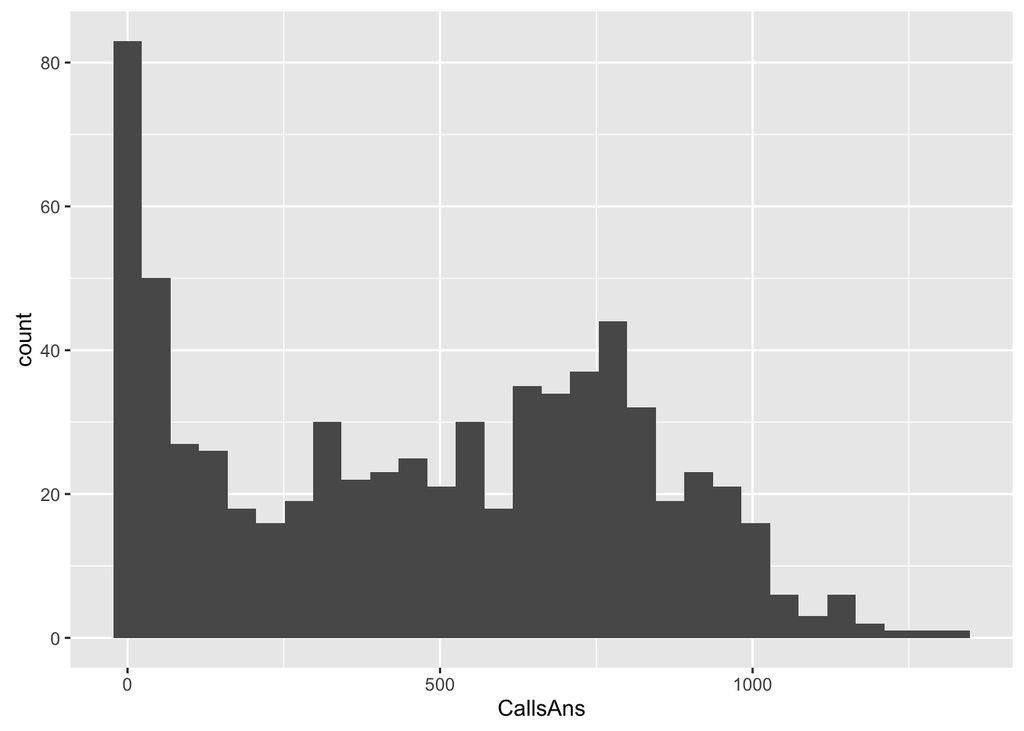

The CableCompany field shows 345 cable companies. However, there are many comapnies which have fewer than 10 calls in the whole month. A distribution of the calls answered by CableCompany is shown below. Some Cable Company names need to be cleaned such as converting lower to upper case etc. After cleaning up, the number of Cable Company reduces to 323.

```
## [1] 345
```

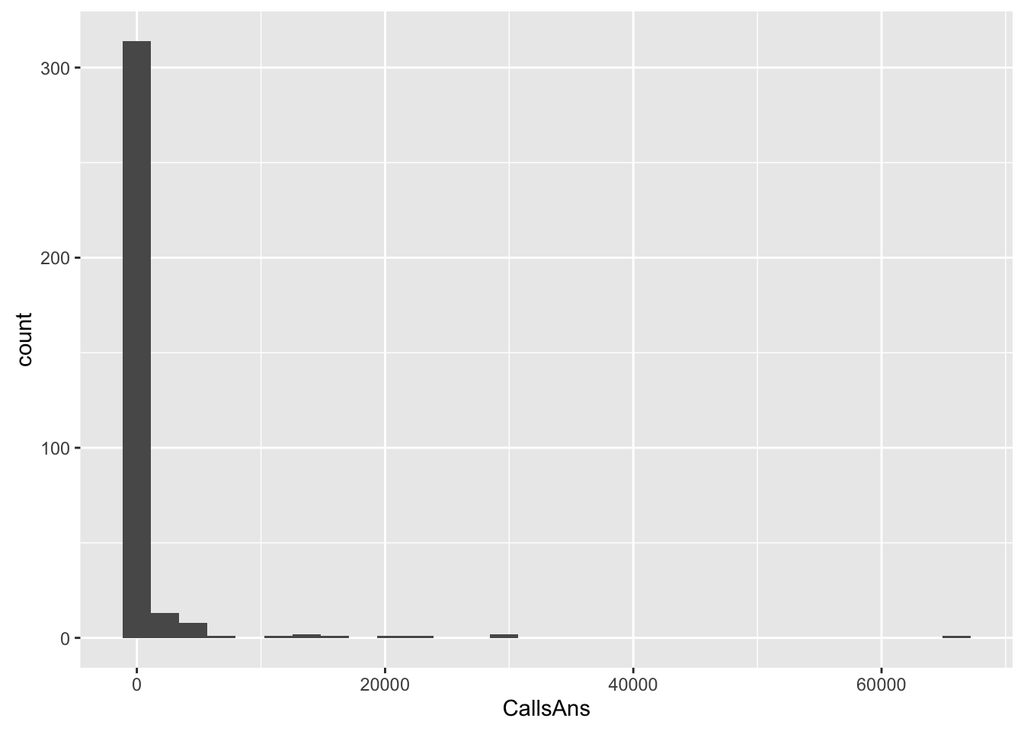

```
##    Min. 1st Qu.  Median    Mean 3rd Qu.    Max.
##       1       4      14     947     181   66030
```

The Affiliate field has 89 unique Affiliates. A distribution of calls answered by affiliate and a summary of the field is shown below. Of the 89 affiliates, 40 affiliates have less than 10 calls answered in May. There are 15 affiliates which have more than 500 calls answered.

```
## [1] 89
```

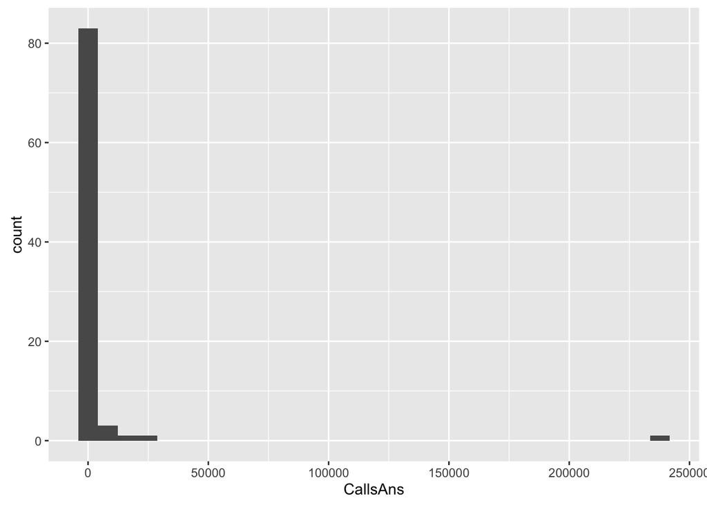

Disposition fields captures the end of call status whether it was a sale or otherwise. Since we are trying to predict whether a call will result in a sale or not and the associated probabilities, the disposition variable to reduced to a sale/no sale variable. 93% of all calls did not result in a sales while sales close rate is roughly 7%.

```
##
##   No Sale      Sale
## 93.114869  6.885131
```

```
##
## No Sale    Sale
##  93.115   6.885
```

```
## [1] "Total number of variables is: 9"
```

```
## [1] "Number of days :  31"
```

```
## [1] "Unique Agents :  689"
```

```
## [1] "Unique TFNs :  5255"
```

```
## [1] "No of area codes :  404"
```

```
## [1] "No of CallSkills :  24"
```

```
## [1] "No of Original Skills :  17"
```

```
## [1] "No of CableCompany :  323"
```

```
## [1] "No of Affiliates :  89"
```

```
## [1] "Percent of CallsDate, Pr(CallsDate)"
```

```
## # A tibble: 31 x 2
##    CallDate PercentOfTot
##       <chr>        <dbl>
## 1    5/1/16     0.020707
## 2   5/10/16     0.039182
## 3   5/11/16     0.037731
## 4   5/12/16     0.034710
## 5   5/13/16     0.035105
## 6   5/14/16     0.023719
## 7   5/15/16     0.017422
## 8   5/16/16     0.041619
## 9   5/17/16     0.037609
## 10  5/18/16     0.035852
## # ... with 21 more rows
```

```
## [1] "Percent of AgentId, Pr(AgentID)"
```

```
## # A tibble: 689 x 2
##    AgentID PercentOfTot
##      <chr>        <dbl>
## 1     5550     0.000383
## 2     5566     0.000006
## 3     5600     0.000018
## 4     5627     0.000606
## 5     5641     0.000046
## 6     5658     0.000028
## 7     5675     0.003318
## 8     5695     0.000187
## 9     5704     0.000009
## 10    5707     0.000122
## # ... with 679 more rows
```

```
## [1] "Percent of TFN, Pr(TFN)"
```

```
## # A tibble: 5,255 x 2
##           TFN PercentOfTot
##         <dbl>        <dbl>
## 1  2153373582     0.000092
## 2  2153373587     0.000009
## 3  2153373636     0.000024
## 4  2153373637     0.000006
## 5  2153373640     0.001004
## 6  2153373641     0.000897
## 7  2153373642     0.000040
## 8  2153373643     0.000018
## 9  2153373644     0.000049
## 10 2153373645     0.000046
## # ... with 5,245 more rows
```

```
## [1] "Percent of CallSkill, Pr(CallSkill)"
```

```
## # A tibble: 24 x 2
##    CallSkill PercentOfTot
##        <int>        <dbl>
## 1        100     0.029645
## 2        101     0.051778
## 3        102     0.047009
## 4        103     0.035607
## 5        108     0.018524
## 6        117     0.007233
## 7        210     0.009489
## 8        222     0.018687
## 9        300     0.064606
## 10       301     0.188795
## # ... with 14 more rows
```

```
## [1] "Percent of OrigSkill, Pr(OrigSkill)"
```

```
## # A tibble: 17 x 2
##    OriginalSkill PercentOfTot
##            <int>        <dbl>
## 1              0     0.000236
## 2            222     0.028151
## 3            300     0.094250
## 4            301     0.316819
## 5            302     0.180824
## 6            303     0.142591
## 7            308     0.085346
## 8            310     0.000355
## 9            313     0.016235
## 10           315     0.004062
## 11           317     0.053421
## 12           328     0.025463
## 13           350     0.015240
## 14           500     0.027520
## 15           501     0.006804
## 16           513     0.002345
## 17           999     0.000337
```

```
## [1] "Percent of CableCompany, Pr(CableCompany)"
```

```
## # A tibble: 323 x 2
##                                CableCompany PercentOfTot
##                                       <chr>        <dbl>
## 1                                               0.000658
## 2                                10Channels     0.000003
## 3                      2TurnItOn - Outbound     0.000533
## 4                                     5LINX     0.000312
## 5                732 Numbers Charter Retail     0.000028
## 6                      732Numbers Earthlink     0.000569
## 7  76766 -\312nuHome Promotions - MSO - TWC     0.000104
## 8     80191 - nuHome Promotions - MSO - COX     0.000101
## 9                                       ADT     0.000070
## 10                                      AOL     0.000003
## # ... with 313 more rows
```

```
## [1] "Percent of Affiliate, Pr(Affiliate)"
```

```
## # A tibble: 89 x 2
##                   Affiliate PercentOfTot
##                       <chr>        <dbl>
## 1                10Channels     0.000003
## 2             2TurnItOn.com     0.000533
## 3                     5LINX     0.000312
## 4           732-Numbers LLC     0.001457
## 5                   ABENITY     0.000006
## 6            AP Media Group     0.000003
## 7              Acceller_DSI     0.000591
## 8               Adknowledge     0.000018
## 9  Advanced Home Protection     0.001491
## 10          All Bundles LLC     0.000003
## # ... with 79 more rows
```

```
## [1] "Percent of AreaCode, Pr(AreaCode)"
```

```
## # A tibble: 404 x 2
##    AreaCode PercentOfTot
##       <chr>        <dbl>
## 1       201     0.003168
## 2       202     0.005993
## 3       203     0.005803
## 4       204     0.000037
## 5       205     0.004637
## 6       206     0.003128
## 7       207     0.003750
## 8       208     0.002479
## 9       209     0.004028
## 10      210     0.006657
## # ... with 394 more rows
```

```
## [1] "Percent of Sale , Pr(C)"
```

```
## # A tibble: 2 x 2
##      Sale PercentOfTot
##     <chr>        <dbl>
## 1 No Sale     0.931149
## 2    Sale     0.068851
```

Probability of each factor level given conversation rate C

```
## [1] "Pr (CallDate | C)"
```

```
## Source: local data frame [31 x 2]
## Groups: CallDate [31]
##
##    CallDate SalesRate
##       <chr>     <dbl>
## 1    5/1/16  0.052476
## 2   5/10/16  0.073822
## 3   5/11/16  0.071145
## 4   5/12/16  0.067637
## 5   5/13/16  0.067312
## 6   5/14/16  0.050587
## 7   5/15/16  0.051300
## 8   5/16/16  0.082298
## 9   5/17/16  0.075608
## 10  5/18/16  0.073679
## # ... with 21 more rows
```

```
## [1] "Pr (AgentID | C)"
```

```
## Source: local data frame [620 x 2]
## Groups: AgentID [620]
##
##    AgentID SalesRate
##      <chr>     <dbl>
## 1     5550  0.032000
## 2     5627  0.075758
## 3     5641  0.066667
## 4     5658  0.111111
## 5     5675  0.071033
## 6     5695  0.049180
## 7     5707  0.175000
## 8     5710  0.136598
## 9     5860  0.028571
## 10    5861  0.061093
## # ... with 610 more rows
```

```
## [1] "Pr (TFN | C)"
```

```
## Source: local data frame [1,441 x 2]
## Groups: TFN [1,441]
##
##           TFN SalesRate
##         <dbl>     <dbl>
## 1  2153373582  0.033333
## 2  2153373587  0.666667
## 3  2153373640  0.064024
## 4  2153373641  0.081911
## 5  2153373642  0.076923
## 6  2153373643  0.333333
## 7  2153373644  0.187500
## 8  2153373645  0.066667
## 9  2153373646  0.147059
## 10 2153373648  0.200000
## # ... with 1,431 more rows
```

```
## [1] "Pr (CallSkill | C)"
```

```
## Source: local data frame [23 x 2]
## Groups: CallSkill [23]
##
##    CallSkill SalesRate
##        <int>     <dbl>
## 1        100  0.096231
## 2        101  0.044337
## 3        102  0.063550
## 4        103  0.075561
## 5        108  0.056345
## 6        117  0.079983
## 7        210  0.077097
## 8        222  0.089762
## 9        300  0.121524
## 10       301  0.055042
## # ... with 13 more rows
```

```
## [1] "Pr (OrigSkill | C)"
```

```
## Source: local data frame [16 x 2]
## Groups: OriginalSkill [16]
##
##    OriginalSkill SalesRate
##            <int>     <dbl>
## 1              0  0.129870
## 2            222  0.085571
## 3            300  0.113568
## 4            301  0.048818
## 5            302  0.066135
## 6            303  0.072835
## 7            308  0.067066
## 8            310  0.043103
## 9            313  0.054487
## 10           315  0.000754
## 11           317  0.081992
## 12           328  0.129703
## 13           350  0.072103
## 14           500  0.067734
## 15           501  0.081871
## 16           513  0.028721
```

```
## [1] "Pr (CableCompany | C)"
```

```
## Source: local data frame [153 x 2]
## Groups: CableCompany [153]
##
##                                CableCompany SalesRate
##                                       <chr>     <dbl>
## 1                                            0.069767
## 2                      2TurnItOn - Outbound  0.017241
## 3                                     5LINX  0.176471
## 4                732 Numbers Charter Retail  0.111111
## 5                      732Numbers Earthlink  0.016129
## 6  76766 -\312nuHome Promotions - MSO - TWC  0.205882
## 7     80191 - nuHome Promotions - MSO - COX  0.181818
## 8                                       ATT  0.095403
## 9                               ATT Spanish  0.054264
## 10               ATT-Touchtone Technologies  0.022590
## # ... with 143 more rows
```

```
## [1] "Pr (Affiliate | C)"
```

```
## Source: local data frame [43 x 2]
## Groups: Affiliate [43]
##
##                                        Affiliate SalesRate
##                                            <chr>     <dbl>
## 1                                  2TurnItOn.com  0.017241
## 2                                          5LINX  0.176471
## 3                                732-Numbers LLC  0.021008
## 4                       Advanced Home Protection  0.182752
## 5                          Broadband Corporation  0.045455
## 6  CJ Communications dba Home Service Connection  0.161145
## 7                                      CLEARLINK  0.146996
## 8                                 CM Enterprises  0.093960
## 9                           Cannon Satellite LLC  0.197605
## 10                             Connect Your Home  0.140354
## # ... with 33 more rows
```

```
## [1] "Pr (AreaCode | C)"
```

```
## Source: local data frame [304 x 2]
## Groups: AreaCode [304]
##
##    AreaCode SalesRate
##       <chr>     <dbl>
## 1       201  0.058937
## 2       202  0.058733
## 3       203  0.060127
## 4       205  0.079868
## 5       206  0.055773
## 6       207  0.078367
## 7       208  0.127160
## 8       209  0.062310
## 9       210  0.055172
## 10      212  0.030303
## # ... with 294 more rows
```

Graphical representation of sales rates by factors:

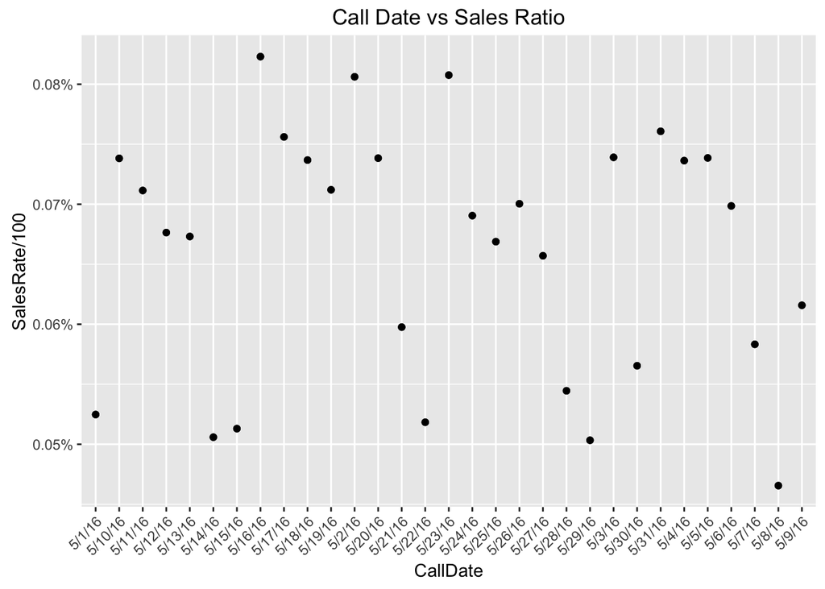

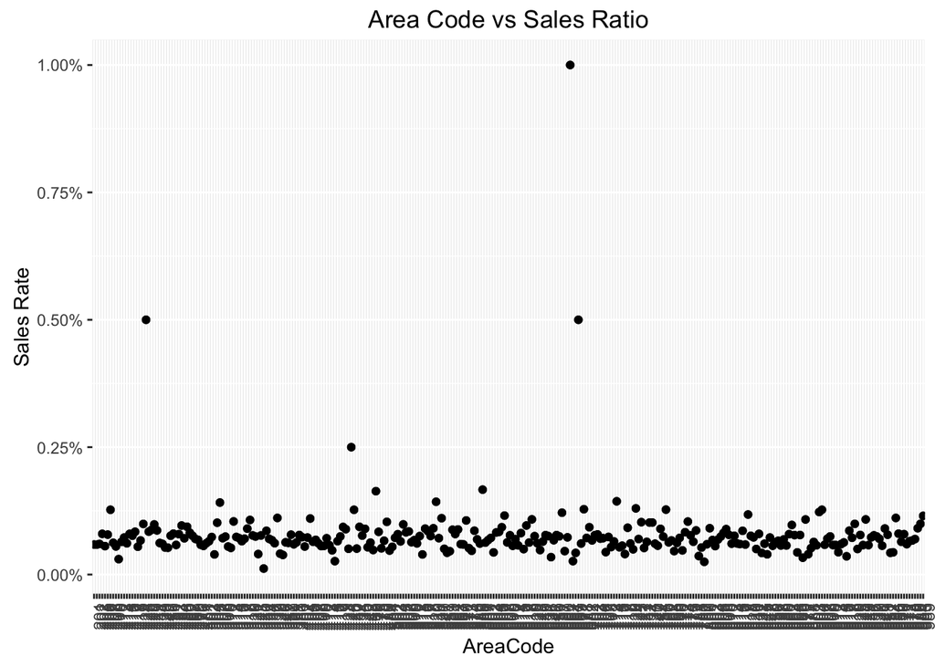

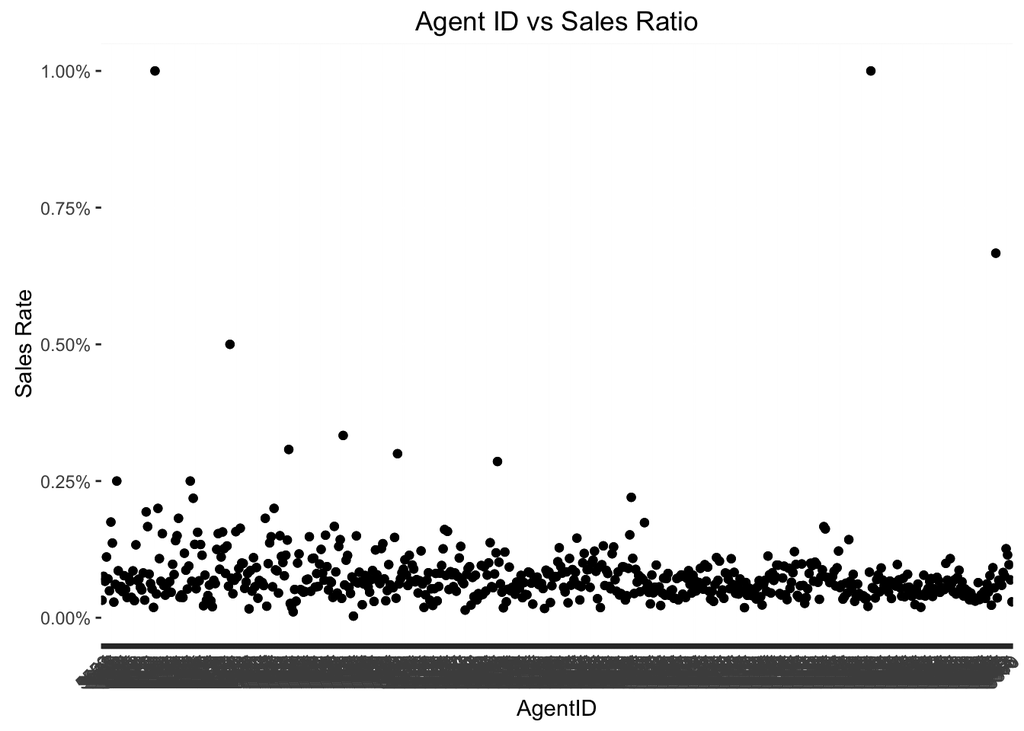

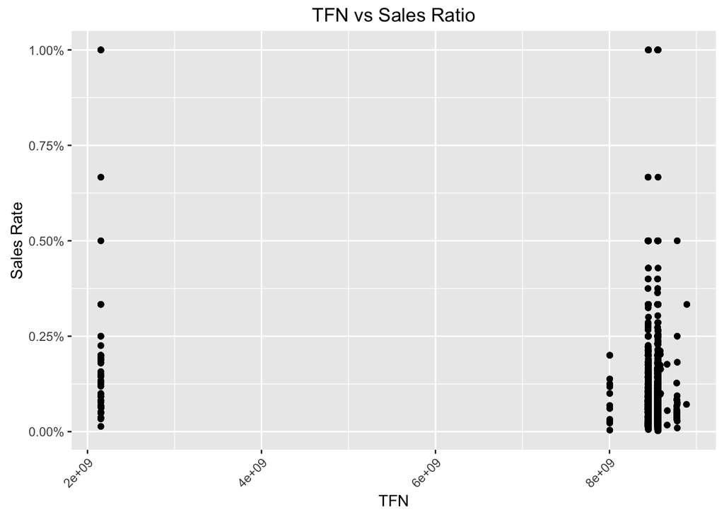

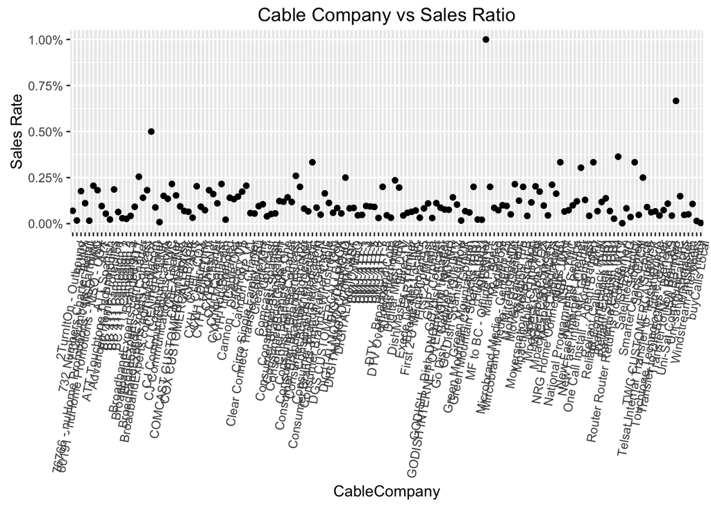

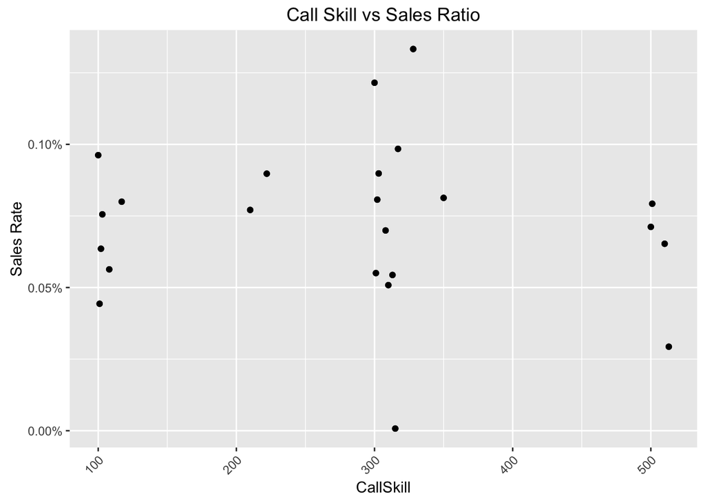

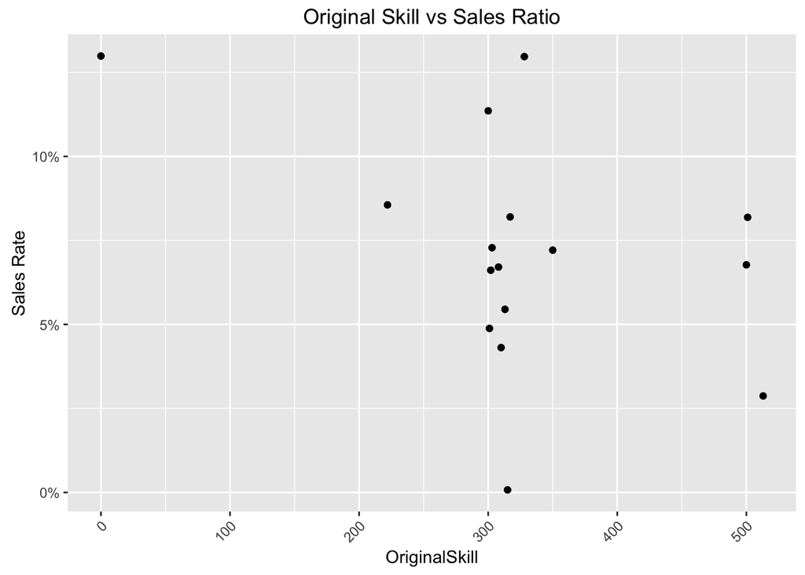

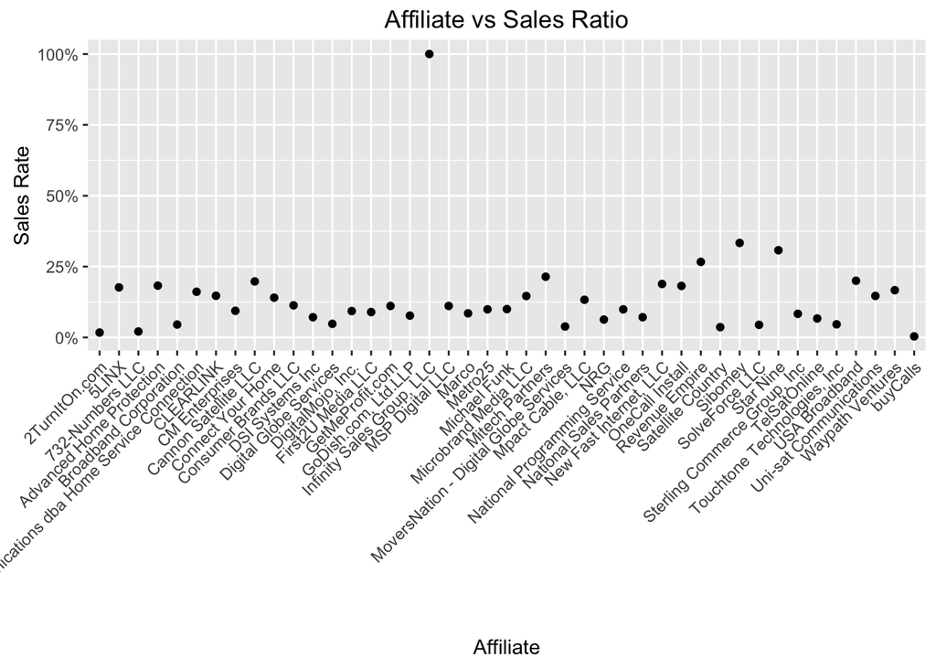

Calculate Bayesian probability for a specific call

Function to predict probability of sale in real time

```
## Analysis of Variance Table
##
## Response: Sale
##                    Df Sum Sq  Mean Sq    F value    Pr(>F)
## Affiliate           8 0.5719 0.071488 3.9739e+29 < 2.2e-16 ***
## AreaCode           76 5.6678 0.074577 4.1456e+29 < 2.2e-16 ***
## Affiliate:AreaCode  4 0.2703 0.067568 3.7560e+29 < 2.2e-16 ***
## Residuals          11 0.0000 0.000000
## ---
## Signif. codes:  0 '***' 0.001 '**' 0.01 '*' 0.05 '.' 0.1 ' ' 1
```

```
##                  Affiliate AreaCode combined.prob
## 2        Connect Your Home      618     1.6292006
## 20               CLEARLINK      262     1.6577806
## 53  Digital Globe Services      714     0.7779130
## 108              CLEARLINK      248     1.3767928
## 121 Digital Globe Services      630     0.6617614
## 146 Digital Globe Services      717     0.7205051
## 169              CLEARLINK      480     1.4694456
## 192 Digital Globe Services      703     0.8623932
## 201      Connect Your Home      774     1.5383448
## 206              CLEARLINK      316     1.5038780
```

Example probabilities:

Area Code : 520, Affiliate : “Consumer Brands LLC”

```
## [1] "1.3 %"
```

Area Code : 664, Affiliate : “CLEARLINK”

```
## [1] "7.9 %"
```

Area Code : 664, “Infinity Sales Group, LLC”

```
## [1] "13.77 %"
```